# TUGAS MPDW PERTEMUAN 4

Author

Rahel Joycelyn Hutagalung

Published

September 17, 2026

# Proses MA(2)

## Pembangkitan Data

Model $MA(2)$ yang dibangkitkan memiliki parameter $\theta_1 = 0.4$ dan $\theta_2 = 0.6$ sebanyak $n = 300$ observasi. Persamaan stokastik untuk model ini dirumuskan sebagai berikut:

$$Y_t = e_t + 0.4e_{t-1} + 0.6e_{t-2}$$

dengan $e_t \sim N(0, \sigma^2)$ merupakan galat white noise.

```r
library(TSA)
set.seed(65)
n <- 300

# Pembangkitan white noise
wn <- rnorm(n)
```

### Manual

```r
ma2_manual <- numeric(n)
ma2_manual[1] <- wn[1]
ma2_manual[2] <- wn[2] + 0.4 * wn[1]
for (i in 3:n) {
  ma2_manual[i] <- wn[i] + 0.4 * wn[i - 1] + 0.6 * wn[i - 2]
}
ma2_manual
```

```
  [1] -1.196820544 -1.430395664 -0.820122927 -1.904487061  0.410857131
  [6]  0.708714832  0.597441806 -0.657934437 -1.388104218 -2.180627957
 [11] -0.499121521  0.672009963  1.131580838 -0.938728920 -0.730222073
 [16]  0.047856500  1.917469019  0.113168533 -1.911457159 -2.472209793
 [21] -3.878360849 -1.273317870 -1.522906623 -0.143570417  0.117186072
 [26] -1.109412079  1.676690586 -0.897114362  2.166332829 -0.278590748
 [31]  0.355349112 -0.004181376  0.703148402  2.097318823  1.572901307
 [36]  1.349915453  0.569276261 -0.632335364  1.057444703 -1.188154793
 [41]  1.315020143 -0.868997361 -2.064857478 -3.624028947 -1.470989469
 [46]  0.274132415  2.050309990 -1.314209735 -1.996629357 -3.013797237
 [51] -1.522660668  0.174148276  1.978365612  0.252769003 -0.854964364
 [56] -0.981281857 -1.103050459 -0.580056096  0.696931593  1.095174318
 [61]  0.607855559  1.050437104  0.744712124  0.311640581  0.317426635
 [66]  1.092844172 -0.515721078 -0.918673710 -1.071679112 -1.489774458
 [71] -0.655970238 -0.258462140  1.047234307  1.023742137  2.826963444
```

[output cut: 45 more lines]

### Pake arima.sim()

```r
ma2_sim <- arima.sim(list(order = c(0, 0, 2), ma = c(0.4, 0.6)), n = n)
ma2_sim
```

```
Time Series:
Start = 1
End = 300
Frequency = 1
  [1]  0.05376069  0.60419826 -1.22822299 -3.03617809 -1.71749507 -2.17218962
  [7]  0.09074085  0.19078718  1.41203940 -0.45995076 -0.90532589 -1.57288983
 [13] -2.60902084  0.19751032 -1.68497146  2.03288260  1.00696955  3.00071528
 [19]  1.02624209 -0.33493633  0.50538296  1.37378537  1.78618362  1.66080980
 [25]  1.26144438  1.49530948  0.90732681  0.35022733 -1.10765298 -0.01413251
 [31] -0.06810461  0.99799922  1.68907056  1.78336774  0.55268993  1.33291728
 [37] -0.05477944 -0.41604937 -0.30676716 -0.45471187  0.30663141  0.52770271
 [43] -0.79284798  1.10988089  0.08540699  0.89230731  1.10621488 -0.72800227
 [49] -0.65741485 -1.69501347 -0.92883588 -0.95609683  0.34793722 -1.42127128
 [55] -0.25533595 -1.54515259 -1.16023176 -0.39286331  0.80146975  0.57644461
 [61]  0.04568312  0.37825360 -0.58244376  1.66545724  1.47212036  3.68117164
```

[output cut: 39 more lines]

## Plot TS, ACF, PACF, EACF, dan Stasioneritas

### Plot Time Series

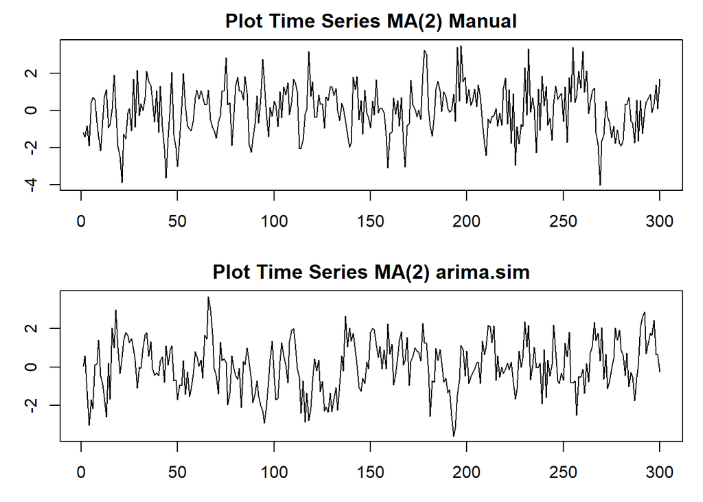

```r
par(mfrow = c(2, 1), mar = c(3, 3, 2, 1))

ts.plot(ma2_manual, main = "Plot Time Series MA(2) Manual", ylab = expression(Y[t]))
ts.plot(ma2_sim, main = "Plot Time Series MA(2) arima.sim", ylab = expression(Y[t]))
```

### Plot Autokorelasi

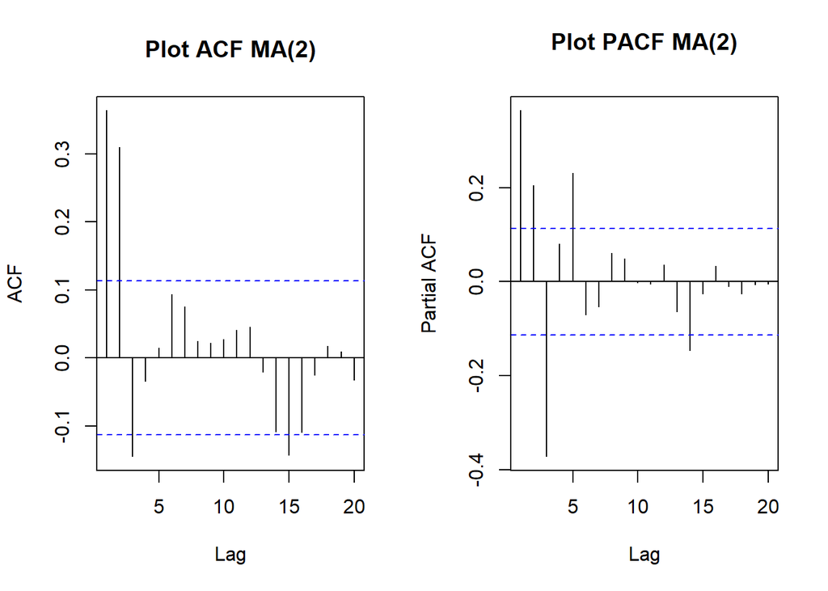

```r
par(mfrow = c(1, 2))
acf(ma2_manual, lag.max = 20, main = "Plot ACF MA(2)")
pacf(ma2_manual, lag.max = 20, main = "Plot PACF MA(2)")
```

### Tabel EACF

```r
eacf(ma2_manual)
```

```
AR/MA
  0 1 2 3 4 5 6 7 8 9 10 11 12 13
0 x x x o o o o o o o o  o  o  o
1 x x x o o o o o o o o  o  o  o
2 x x o o o o o o o o o  o  o  o
3 x x o x x o o o o o o  o  o  o
4 x x x x o o o o o o o  o  o  o
5 x x x x x o o o o o o  o  o  o
6 x x x o x o o o o o o  o  o  o
7 x x x o x o o o x o o  o  o  o
```

Berdasarkan plot time series, pergerakan data tebaran fluktuasi berada di sekitar rataan konstan $E[Y_t] = 0$ dan ragamnya $\text{Var}(Y_t) = \sigma_e^2(1 + \theta_1^2 + \theta_2^2)$ bersifat konstan seiring perubahan waktu ($t$). Hal ini menandakan bahwa proses $MA(2)$ yang dibangkitkan stasioner dalam rataan maupun ragam.

## Scatterplot Yt dengan sesamanya

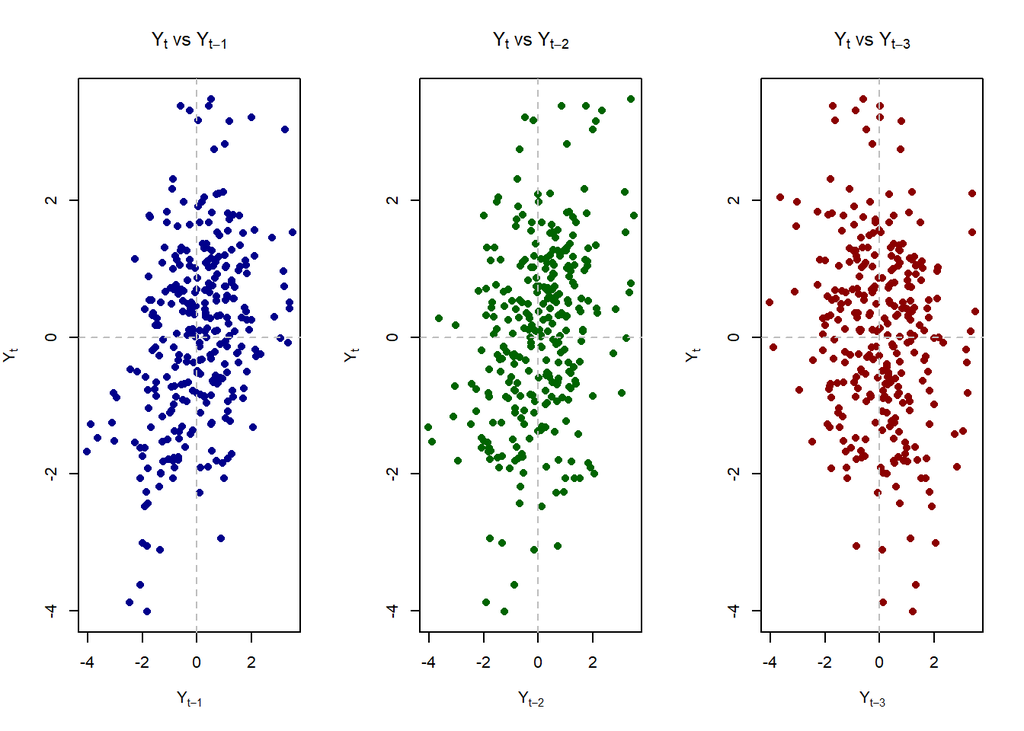

```r
yt   <- ma2_manual[4:n]
yt_1 <- ma2_manual[3:(n - 1)]
yt_2 <- ma2_manual[2:(n - 2)]
yt_3 <- ma2_manual[1:(n - 3)]

par(mfrow = c(1, 3))
plot(yt_1, yt, main = expression(paste(Y[t], " vs ", Y[t-1])),
     xlab = expression(Y[t-1]), ylab = expression(Y[t]), col = "darkblue", pch = 16)
abline(h = 0, v = 0, lty = 2, col = "gray")

plot(yt_2, yt, main = expression(paste(Y[t], " vs ", Y[t-2])),
     xlab = expression(Y[t-2]), ylab = expression(Y[t]), col = "darkgreen", pch = 16)
abline(h = 0, v = 0, lty = 2, col = "gray")

plot(yt_3, yt, main = expression(paste(Y[t], " vs ", Y[t-3])),
     xlab = expression(Y[t-3]), ylab = expression(Y[t]), col = "darkred", pch = 16)
abline(h = 0, v = 0, lty = 2, col = "gray")
```

1. Hubungan $Y_t$ dengan $Y_{t-1}$: Scatterplot membentuk pola linier positif sedang mencerminkan adanya autokorelasi positif sebesar $\rho_1 \approx 0.421$.
2. Hubungan $Y_t$ dengan $Y_{t-2}$: Scatterplot masih menunjukkan pola linier positif dengan kekuatan yang hampir sama ($\rho_2 \approx 0.395$).
3. Hubungan $Y_t$ dengan $Y_{t-3}$: Scatterplot cenderung memencar secara acak tanpa pola linier yang jelas. Hal ini mengonfirmasi bahwa untuk lag $k \ge 3$, nilai korelasi teoritis bernilai nol ($\rho_k = 0$).

## Perhitungan Autokorelasi

### Dari Data Bangkitan

```r
rho_sample <- acf(ma2_manual, lag.max = 3, plot = FALSE)$acf[1:4]

t1 <- 0.4
t2 <- 0.6
denom <- 1 + t1^2 + t2^2

rho_teoritis <- c(
  1,
  (t1 + t1 * t2) / denom,
  t2 / denom,
  0
)

tabel_korelasi <- data.frame(
  Lag = 0:3,
  Nilai_Teoritis = round(rho_teoritis, 5),
  Sampel_Manual = round(rho_sample, 5)
)
tabel_korelasi
```

```
  Lag Nilai_Teoritis Sampel_Manual
1   0        1.00000       0.36393
2   1        0.42105       0.30991
3   2        0.39474      -0.14471
4   3        0.00000            NA
```

### Teoritis

Autokorelasi teoritis pada lag ke-$k$ ($\rho_k$) didefinisikan sebagai $\rho_k = \frac{\gamma_k}{\gamma_0}$:

1. Ragam / Autokovarians Lag-0 ($\gamma_0$):
   $$\gamma_0 = \text{Var}(Y_t) = \sigma_e^2(1 + \theta_1^2 + \theta_2^2) = \sigma_e^2(1 + 0.4^2 + 0.6^2) = 1.52\sigma_e^2$$
2. Autokovarians dan Autokorelasi Lag-1 ($\rho_1$):
   $$\gamma_1 = \sigma_e^2(\theta_1 + \theta_1\theta_2) = \sigma_e^2(0.4 + 0.4 \times 0.6) = 0.64\sigma_e^2$$
   $$\rho_1 = \frac{0.64}{1.52} = \frac{8}{19} \approx 0.42105$$
3. Autokovarians dan Autokorelasi Lag-2 ($\rho_2$):
   $$\gamma_2 = \sigma_e^2(\theta_2) = 0.6\sigma_e^2$$
   $$\rho_2 = \frac{0.6}{1.52} = \frac{15}{38} \approx 0.39474$$
4. Autokorelasi Lag $k \ge 3$ ($\rho_k$):
   $$\rho_k = 0 \quad \forall k \ge 3$$

# Proses AR(2)

## Pembangkitan Model

Model $AR(2)$ yang dibangkitkan memiliki parameter $\phi_1 = 0.5$ dan $\phi_2 = 0.2$ sebanyak $n = 300$ observasi. Persamaan stokastiknya dirumuskan sebagai berikut:
$$Y_t = 0.5Y_{t-1} + 0.2Y_{t-2} + e_t$$
dengan $e_t \sim N(0, \sigma^2)$ merupakan galat white noise.

```r
library(TSA)

set.seed(65)
n <- 300

wn <- rnorm(n)
```

### Manual

```r
ar2_manual <- numeric(n)
ar2_manual[1] <- wn[1]
ar2_manual[2] <- 0.5 * ar2_manual[1] + wn[2]
for (i in 3:n) {
  ar2_manual[i] <- 0.5 * ar2_manual[i - 1] + 0.2 * ar2_manual[i - 2] + wn[i]
}
ar2_manual
```

```
  [1] -1.19682054 -1.55007772 -0.73576659 -2.12283998 -0.38692155  0.62899004
  [7] -0.15724606 -1.20122804 -1.28419218 -2.05307627 -0.92292689  0.35819213
 [13]  0.41771339 -1.56567738 -0.94497071  0.46820905  1.60845227 -0.36659820
 [19] -2.20528448 -1.95202165 -3.57879916 -2.12279334 -2.02582849 -1.51578088
 [25] -0.86534369 -1.91734030  0.83892914 -0.94047769  1.07206868  0.10542390
 [31] -0.10523226  0.25873939  0.91877811  2.11011136  1.68584992  1.47666258
 [37]  1.29186823  0.09535527  1.57204036 -0.38191238  1.15368003 -0.06842892
 [43] -2.25891823 -3.44366606 -1.25113381 -0.02884815  0.71798865 -2.12531202
 [49] -2.51385664 -2.57074659 -1.99842393 -0.72184776  1.02731912 -0.56802022
 [55] -1.63134323 -0.72705260 -0.94205646 -1.21692407  0.29160930  0.92249230
 [61]  0.06630500  0.83734979  1.20072629  0.40013823  0.44344472  1.61391896
 [67] -0.14687844 -1.03961977 -0.47976283 -1.19197032 -1.09189563 -0.43632189
 [73]  0.71146098  0.62419583  2.45026104  0.63321519  0.30389635 -0.98135602
 [79] -0.20599972  1.68219013  1.66581880  0.69489578  1.39410017  1.38122366
 [85]  2.14287206  1.48271537 -1.43163566 -1.72286610 -0.60813565 -0.83760276
```

[output cut: 35 more lines]

### Pake arima.sim

```r
ar2_sim <- arima.sim(list(order = c(2, 0, 0), ar = c(0.5, 0.2)), n = n)
```

## Plot TS, ACF, PACF, EACF, dan Stasioneritas

### Plot Time Series

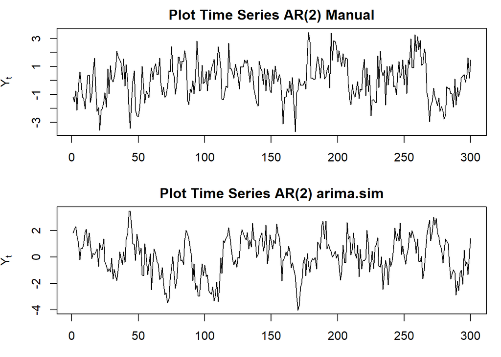

```r
par(mfrow = c(2, 1), mar = c(3, 4, 2, 1))
ts.plot(ar2_manual, main = "Plot Time Series AR(2) Manual", ylab = expression(Y[t]))
ts.plot(ar2_sim, main = "Plot Time Series AR(2) arima.sim", ylab = expression(Y[t]))
```

### Plot ACF dan PACF

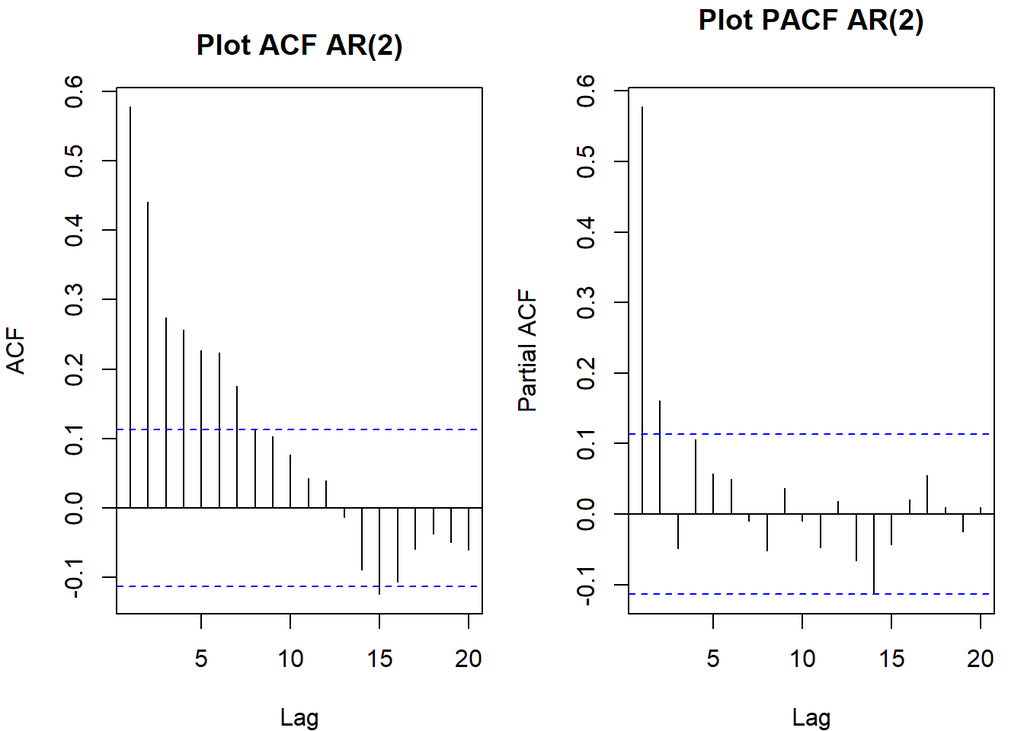

```r
par(mfrow = c(1, 2), mar = c(4, 4, 3, 1))
acf(ar2_manual, lag.max = 20, main = "Plot ACF AR(2)")
pacf(ar2_manual, lag.max = 20, main = "Plot PACF AR(2)")
```

### Tabel EACF

```r
eacf(ar2_manual)
```

```
AR/MA
  0 1 2 3 4 5 6 7 8 9 10 11 12 13
0 x x x x x x x o o o o  o  o  o
1 x x x o o o o o o o o  o  o  o
2 x o x o o o o o o o o  o  o  o
3 x x x o o o o o o o o  o  o  o
4 x o x o o o o o o o o  o  o  o
5 x x x o x o o o o o o  o  o  o
6 x x x x o x o o o o o  o  o  o
7 x x x x o o o o o o o  o  o  o
```

Persamaan karakteristik $AR(2)$: $1 - 0.5B - 0.2B^2 = 0$. Akar-akarnya memenuhi syarat kestasioneran $\vert{}\phi_2\vert{} = \vert{}0.2\vert{} < 1$, $\phi_1 + \phi_2 = 0.7 < 1$, dan $\phi_2 - \phi_1 = -0.3 < 1$. Pergerakan data tampak berfluktuasi secara konstan di sekitar nilai harapan $E[Y_t] = 0$ dengan ragam yang stabil, menandakan data stasioner dalam rataan dan ragam.

## Scatterplot

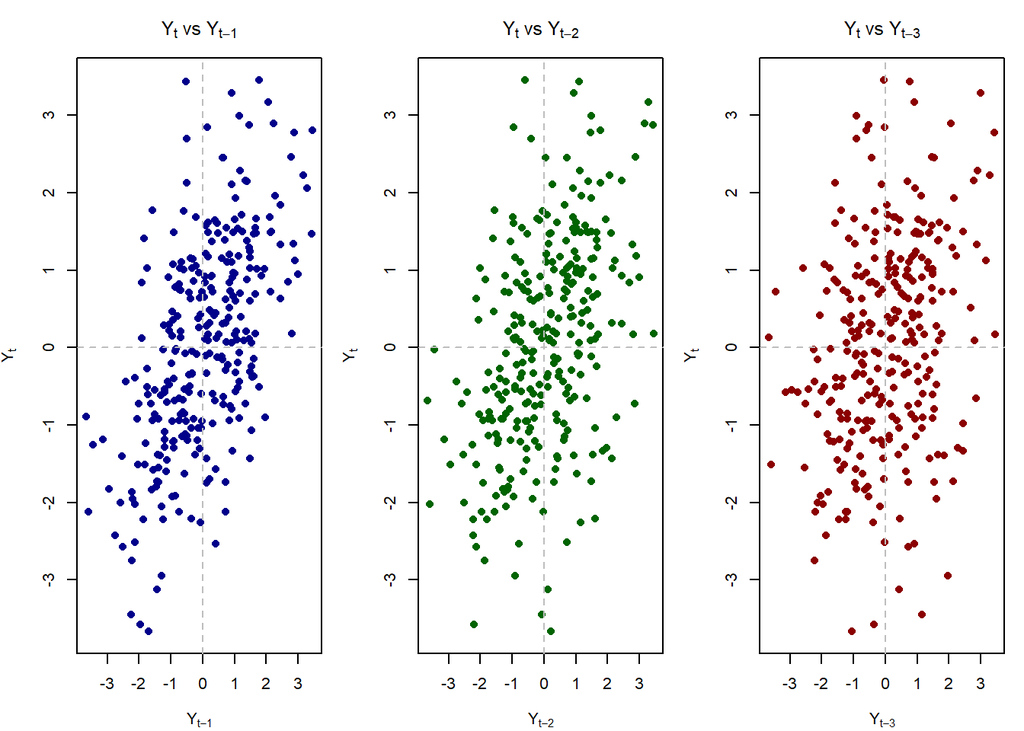

```r
yt   <- ar2_manual[4:n]
yt_1 <- ar2_manual[3:(n - 1)]
yt_2 <- ar2_manual[2:(n - 2)]
yt_3 <- ar2_manual[1:(n - 3)]

par(mfrow = c(1, 3), mar = c(4, 4, 3, 1))
plot(yt_1, yt, main = expression(paste(Y[t], " vs ", Y[t-1])),
     xlab = expression(Y[t-1]), ylab = expression(Y[t]), col = "darkblue", pch = 16)
abline(h = 0, v = 0, lty = 2, col = "gray")

plot(yt_2, yt, main = expression(paste(Y[t], " vs ", Y[t-2])),
     xlab = expression(Y[t-2]), ylab = expression(Y[t]), col = "darkgreen", pch = 16)
abline(h = 0, v = 0, lty = 2, col = "gray")

plot(yt_3, yt, main = expression(paste(Y[t], " vs ", Y[t-3])),
     xlab = expression(Y[t-3]), ylab = expression(Y[t]), col = "darkred", pch = 16)
abline(h = 0, v = 0, lty = 2, col = "gray")
```

1. Hubungan $Y_t$ dengan $Y_{t-1}$ membentuk pola hubungan linier positif kuat ($\rho_1 \approx 0.625$) yang mencerminkan ketergantungan langsung yang besar pada 1 periode sebelumnya.
2. Hubungan $Y_t$ dengan $Y_{t-2}$ membentuk pola linier positif sedang ($\rho_2 \approx 0.5125$).
3. Hubungan $Y_t$ dengan $Y_{t-3}$ membentuk pola linier yang mulai meluruh tetapi masih menunjukkan korelasi ($\rho_3 \approx 0.381$). Berbeda dengan model MA, pada proses AR nilai korelasi terus berlanjut secara meluruh (tails off) untuk seluruh lag $k$.

## Perhitungan Autokorelasi

### Dari Data Bangkitan

```r
rho_sample2 <- acf(ar2_manual, lag.max = 3, plot = FALSE)$acf[1:4]

# Autokorelasi Teoritis Yule-Walker
p12 <- 0.5
p22 <- 0.2

rho0_t <- 1
rho1_t <- p12 / (1 - p22)
rho2_t <- (p12 * rho1_t) + (p22 * rho0_t)
rho3_t <- (p12 * rho2_t) + (p22 * rho1_t)

rho_teoritis2 <- c(rho0_t, rho1_t, rho2_t, rho3_t)

# Menyusun Tabel Perbandingan
tabel_korelasi_ar2 <- data.frame(
  Lag = 0:3,
  Nilai_Teoritis = round(rho_teoritis2, 5),
  Sampel_Manual = round(rho_sample2, 5)
)
tabel_korelasi_ar2
```

```
  Lag Nilai_Teoritis Sampel_Manual
1   0        1.00000       0.57732
2   1        0.62500       0.44052
3   2        0.51250       0.27439
4   3        0.38125            NA
```

### Teoritis

Untuk proses $AR(2)$ dengan $\phi_1 = 0.5$ dan $\phi_2 = 0.2$:

1. Lag 0 ($\rho_0$):
   $$\rho_0 = 1$$
2. Lag 1 ($\rho_1$):
   $$\rho_1 = \frac{\phi_1}{1 - \phi_2} = \frac{0.5}{1 - 0.2} = \frac{0.5}{0.8} = 0.625$$
3. Lag 2 ($\rho_2$):
   $$\rho_2 = \phi_1 \rho_1 + \phi_2 \rho_0 = (0.5 \times 0.625) + (0.2 \times 1) = 0.3125 + 0.2 = 0.5125$$
4. Lag 3 ($\rho_3$):
   $$\rho_3 = \phi_1 \rho_2 + \phi_2 \rho_1 = (0.5 \times 0.5125) + (0.2 \times 0.625) = 0.25625 + 0.125 = 0.38125$$

# Proses ARMA(2,2)

## Pembangkitan Data

Model $ARMA(2,2)$ yang dibangkitkan memiliki parameter $\phi_1 = 0.5$, $\phi_2 = 0.2$, $\theta_1 = 0.4$, dan $\theta_2 = 0.6$ sebanyak $n = 300$ observasi. Persamaan umum stokastiknya dirumuskan sebagai:
$$Y_t = 0.5Y_{t-1} + 0.2Y_{t-2} + e_t + 0.4e_{t-1} + 0.6e_{t-2}$$
dengan $e_t \sim N(0, \sigma^2)$ merupakan galat white noise.

```r
library(TSA)

set.seed(65)
n_obs <- 300

wn_arma22 <- rnorm(n_obs)
```

### Manual

```r
arma22_manual <- numeric(n_obs)

arma22_manual[1] <- wn_arma22[1]
arma22_manual[2] <- 0.5 * arma22_manual[1] + wn_arma22[2] + 0.4 * wn_arma22[1]

for (i in 3:n_obs) {
  arma22_manual[i] <- 0.5 * arma22_manual[i - 1] + 0.2 * arma22_manual[i - 2] +
                      wn_arma22[i] + 0.4 * wn_arma22[i - 1] + 0.6 * wn_arma22[i - 2]
}
arma22_manual
```

```
  [1] -1.196820544 -2.028805935 -2.073890003 -3.347193250 -1.677517495
  [6] -0.799482565 -0.137802975 -0.886732438 -1.859031032 -3.287489961
 [11] -2.514672708 -1.242824383  0.007234105 -1.183676744 -1.320613624
 [16] -0.849185661  1.228753464  0.557708133 -1.386852400 -3.054094366
 [21] -5.682778512 -4.725526000 -5.022225325 -3.599788279 -2.687153133
 [26] -3.172946301 -0.447213191 -1.755310218  1.199235082 -0.030035251
 [31]  0.580178503  0.279900826  0.959134516  2.632866246  3.081161333
 [36]  3.417069369  2.894043212  1.498100115  2.385303403  0.304116931
 [41]  1.944139289  0.163895670 -1.594081785 -4.388290705 -3.983951178
 [46] -2.595501315 -0.044230903 -1.855425450 -2.933188263 -4.851476459
 [51] -4.535036550 -3.063665290 -0.460474343 -0.590201227 -1.242159846
 [56] -1.720402026 -2.211683441 -2.029978221 -0.760394206  0.308981570
 [61]  0.610267503  1.417367170  1.575449209  1.382838619  1.323935787
 [66]  2.031379789  0.764755974 -0.130019765 -0.983737800 -2.007647310
 [71] -1.856541453 -1.588262328 -0.118205148  0.646987097  3.126815963
```

[output cut: 45 more lines]

### Pake arima.sim

```r
arma22_sim <- arima.sim(list(order = c(2, 0, 2), ar = c(0.5, 0.2), ma = c(0.4, 0.6)), n = n_obs)
```

## Plot TS, ACF, PACF, EACF, dan Stasioneritas

### Plot Time Series

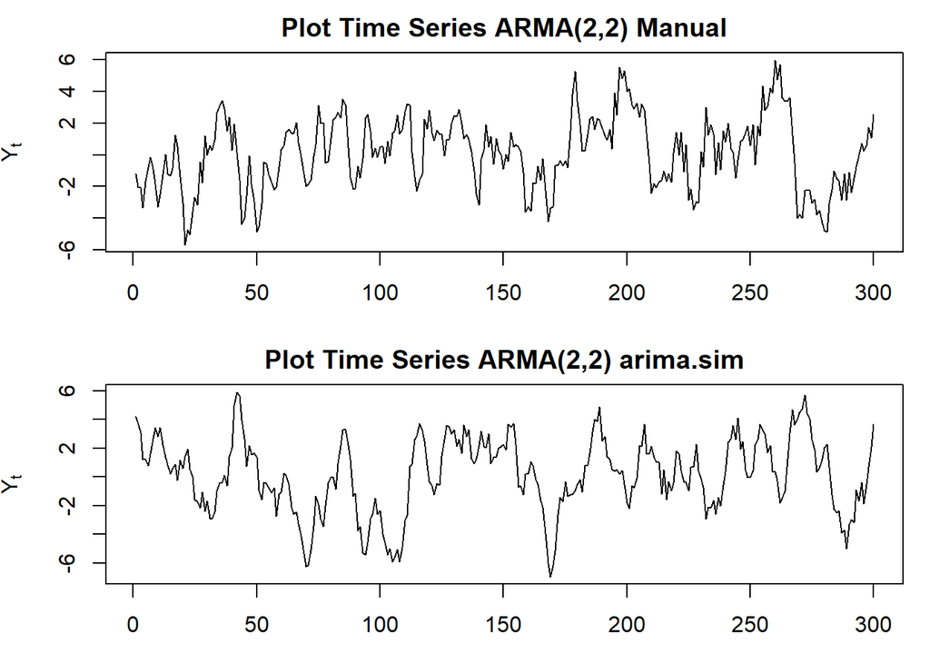

```r
par(mfrow = c(2, 1), mar = c(3, 4, 2, 1))
ts.plot(arma22_manual, main = "Plot Time Series ARMA(2,2) Manual", ylab = expression(Y[t]))
ts.plot(arma22_sim, main = "Plot Time Series ARMA(2,2) arima.sim", ylab = expression(Y[t]))
```

### Plot ACF dan PACF

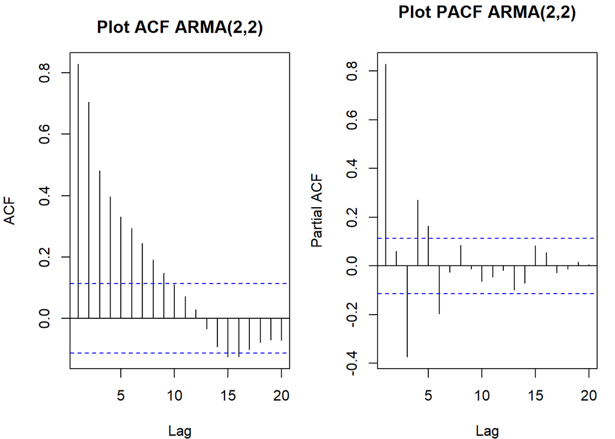

```r
par(mfrow = c(1, 2), mar = c(4, 4, 3, 1))
acf(arma22_manual, lag.max = 20, main = "Plot ACF ARMA(2,2)")
pacf(arma22_manual, lag.max = 20, main = "Plot PACF ARMA(2,2)")
```

### Plot EACF

```r
eacf(arma22_manual)
```

```
AR/MA
  0 1 2 3 4 5 6 7 8 9 10 11 12 13
0 x x x x x x x x x o o  o  o  o
1 o x x o o o o o o o o  o  o  o
2 x x x o o o o o o o o  o  o  o
3 x x x x x o o o o o o  o  o  o
4 x x x x o o o o o o o  o  o  o
5 x x x o o o o o o o o  o  o  o
6 o x o x o o o o o o o  o  o  o
7 x x o o o o o o o o o  o  o  o
```

Persamaan komponen AR: $1 - 0.5B - 0.2B^2 = 0$. Karena akar-akar polinomialnya terletak di luar lingkaran satuan ($\vert{}\phi_2\vert{} = 0.2 < 1$), maka proses $ARMA(2,2)$ ini stasioner dalam rataan dan ragam. Hal ini diperkuat oleh plot time series yang berfluktuasi stabil di sekitar rataan $E[Y_t] = 0$.

## Scatterplot

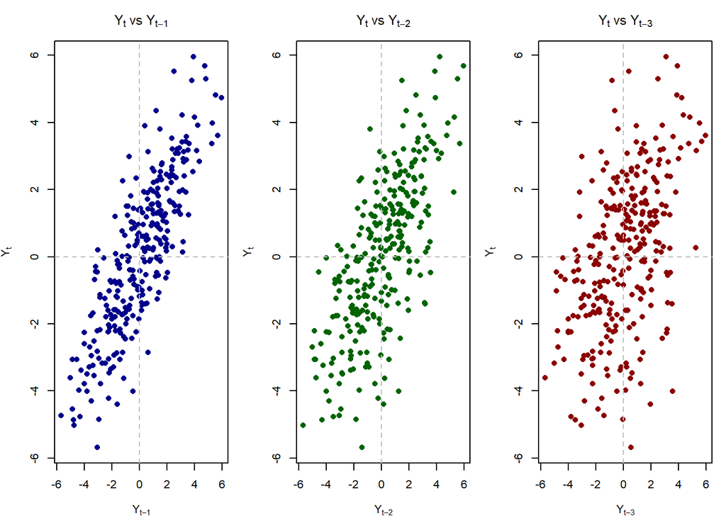

```r
yt_arma22   <- arma22_manual[4:n_obs]
yt_1_arma22 <- arma22_manual[3:(n_obs - 1)]
yt_2_arma22 <- arma22_manual[2:(n_obs - 2)]
yt_3_arma22 <- arma22_manual[1:(n_obs - 3)]

par(mfrow = c(1, 3), mar = c(4, 4, 3, 1))
plot(yt_1_arma22, yt_arma22, main = expression(paste(Y[t], " vs ", Y[t-1])),
     xlab = expression(Y[t-1]), ylab = expression(Y[t]), col = "darkblue", pch = 16)
abline(h = 0, v = 0, lty = 2, col = "gray")

plot(yt_2_arma22, yt_arma22, main = expression(paste(Y[t], " vs ", Y[t-2])),
     xlab = expression(Y[t-2]), ylab = expression(Y[t]), col = "darkgreen", pch = 16)
abline(h = 0, v = 0, lty = 2, col = "gray")

plot(yt_3_arma22, yt_arma22, main = expression(paste(Y[t], " vs ", Y[t-3])),
     xlab = expression(Y[t-3]), ylab = expression(Y[t]), col = "darkred", pch = 16)
abline(h = 0, v = 0, lty = 2, col = "gray")
```

1. Hubungan $Y_t$ vs $Y_{t-1}$ membentuk pola hubungan linier positif yang sangat kuat dipicu oleh kombinasi bobot $\phi_1 = 0.5$ dan $\theta_1 = 0.4$.
2. Hubungan $Y_t$ vs $Y_{t-2}$ memperlihatkan keterikatan linier positif tingkat menengah.
3. Hubungan $Y_t$ vs $Y_{t-3}$. Seiring bertambahnya lag, tebaran titik meluruh namun tetap menyisakan pola linier halus khas sifat tails off dari komponen autoregresif.

## Perhitungan Autokorelasi

### Dari Data Bangkitan

```r
phi_vec   <- c(0.5, 0.2)
theta_vec <- c(0.4, 0.6)

rho_arma22_teoritis <- ARMAacf(ar = phi_vec, ma = theta_vec, lag.max = 3)

rho_arma22_sample <- acf(arma22_manual, lag.max = 3, plot = FALSE)$acf[1:4]

tabel_arma22 <- data.frame(
  Lag = 0:3,
  Nilai_Teoritis = round(as.vector(rho_arma22_teoritis), 5),
  Sampel_Manual  = round(as.vector(rho_arma22_sample), 5)
)

tabel_arma22
```

```
  Lag Nilai_Teoritis Sampel_Manual
1   0        1.00000       0.82805
2   1        0.85920       0.70504
3   2        0.74919       0.48192
4   3        0.54644            NA
```

### Teoritis

Parameter model: $\phi_1 = 0.5, \phi_2 = 0.2, \theta_1 = 0.4, \theta_2 = 0.6$.

Sistem persamaan autokovarians ($\gamma_k$) diperoleh dari pengalihan $Y_t$ dengan lag-nya:

$$\gamma_0 = \phi_1 \gamma_1 + \phi_2 \gamma_2 + \sigma_e^2(1 + \theta_1^2 + \theta_2^2 + \theta_1\phi_1 + \theta_2\phi_2 + \theta_1\theta_2\phi_1)$$

$$\gamma_1 = \phi_1 \gamma_0 + \phi_2 \gamma_1 + \sigma_e^2(\theta_1 + \theta_1\theta_2 + \theta_2\phi_1)$$

$$\gamma_2 = \phi_1 \gamma_1 + \phi_2 \gamma_0 + \sigma_e^2(\theta_2)$$

$$\gamma_k = \phi_1 \gamma_{k-1} + \phi_2 \gamma_{k-2} \quad \forall k \ge 3$$

Dengan membagi seluruh persamaannya terhadap $\gamma_0$, diperoleh autokorelasi teoritis $\rho_k = \frac{\gamma_k}{\gamma_0}$ seperti tabel dari data bangkitan